# Lab 6 Regularization Michał Stawikowski

```python
import numpy as np
import pandas as pd
import matplotlib.pyplot as plt
import matplotlib
from sklearn.metrics import accuracy_score
from sklearn.metrics import log_loss
import seaborn as sns
import warnings
warnings.simplefilter("ignore")
%matplotlib inline

plt.rcParams["figure.figsize"] = (12, 8)
plt.style.use("bmh")
font = {'family' : 'normal',
        'weight' : 'bold',
        'size'   : 22}

matplotlib.rc('font', **font)
```

# Implementation

## New stuff

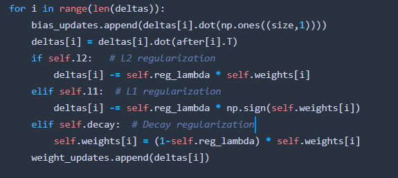

```python
# L1, L2, Decay regularization
from IPython.display import Image
Image("C:/Users/jaiko/Desktop/regularization.png")
```

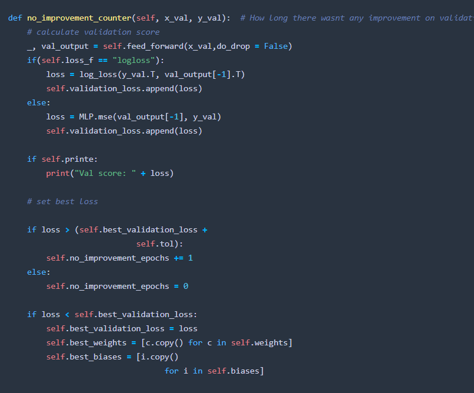

```python
# Early stopping when there is no improvement on validation data
from IPython.display import Image
Image("C:/Users/jaiko/Desktop/counter.png")
```

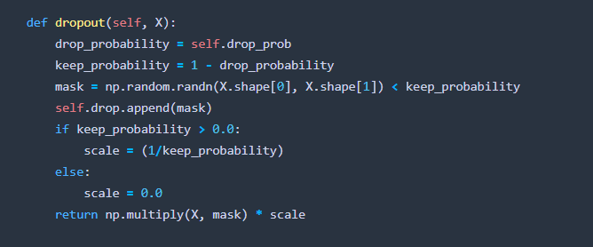

```python
# Dropout
from IPython.display import Image
Image("C:/Users/jaiko/Desktop/dropout.png")
```

# Full implementation of neural network

```python
#neural network
class MLP():
    def __init__(self, layers, activations, init= "normal", loss_f = "mse", printe = False,
                iter_with_no_change = 20, tol = 1e-4, early_stopping = False, reg_lambda = 0.1,
                l1 = False, l2 = False, decay = False, drop_prob = False):

        self.printe = printe
        self.loss_f = loss_f
        self.init = init
        self.layers = layers
        self.iter_with_no_change = iter_with_no_change
        self.tol = tol  #New parameters for regularization
        self.early_stopping = early_stopping
        self.reg_lambda = reg_lambda
        self.l1 = l1
        self.l2 = l2
        self.decay = decay
        self.drop_prob = drop_prob

        #List of functions
        self.activations = activations

        #Initialize layers
        self.weights = []
        self.biases = []

        ##normal distribution(0,1)
        if(init == "normal"):
            for i in range(len(layers)-1):
                self.weights.append(np.random.randn(layers[i+1], layers[i]))
                self.biases.append(np.random.randn(layers[i+1], 1))
        ##uniform distribution(0,1)
        elif(init == "uniform"):
            for i in range(len(layers)-1):
                self.weights.append(np.random.uniform(low=0.0, high=1.0,size=(layers[i+1], layers[i])))
                self.biases.append(np.random.uniform(low=0.0, high=1.0,size=(layers[i+1], 1)))
        ##He initialization, biases -> 0  WARNING! Only with specific activation functions
        elif(init == "he"):
            for i in range(len(layers)-1):
                self.weights.append(np.random.randn(layers[i+1], layers[i])*np.sqrt(1/layers[i]))
                self.biases.append(np.zeros((layers[i+1], 1)))
        ##Xavier initialization, biases -> 0 WARNING! Only with specific activation functions
        elif(init == "xavier"):
            for i in range(len(layers)-1):
                self.weights.append(np.random.randn(layers[i+1], layers[i])*np.sqrt(6/(layers[i]
                                                                                       + layers[i+1])))
                self.biases.append(np.zeros((layers[i+1], 1)))



    #Used loss function
    def mse(y_true, y_pred):
        return np.square(np.subtract(y_true,y_pred)).mean()

    #Setting activation function
    def sigmoid(x):
        return np.exp(x)/(1+np.exp(x))

    def linear(x):
        return x

    def tanh(x):
        t=(np.exp(x)-np.exp(-x))/(np.exp(x)+np.exp(-x))
        return t

    def relu(x):
        y = np.copy(x)
        y[y<0] = 0
        return y

    def softmax(x):
        x = x.T
        e = np.exp(x-np.max(x))
        s = np.sum(e, axis=1, keepdims=True)
        w = (e/s)
        w = (e/s).T
        return w

    def softmax2(x):
        e = np.exp(x-np.max(x))
        s = np.sum(e, axis=1, keepdims=True)
        w = (e/s)
        return w

    #Setting derivative of an activation function
    def sigmoid_der(x):
        return MLP.sigmoid(x)*(1-MLP.sigmoid(x))

    def linear_der(x):
        return 1

    def tanh_der(x):
        t=(np.exp(x)-np.exp(-x))/(np.exp(x)+np.exp(-x))
        dt=1-t**2
        return dt

    def relu_der(x):
        y = np.copy(x)
        y[y>=0] = 1
        y[y<0] = 0
        return y

    def softmax_der(der, z):
        der = der.T
        z = z.T
        m, n = z.shape
        w = MLP.softmax2(z)
        vector1 = np.einsum('ij,ik->ijk', w, w)
        vector2 = np.einsum('ij,jk->ijk', w, np.eye(n, n))
        delta = vector2 - vector1
        final = np.einsum('ijk,ik->ij', delta, der)
        final = final.T
        return final

    def no_improvement_counter(self, x_val, y_val):  # How long there wasnt any improvement on validation data
        # calculate validation score
        _, val_output = self.feed_forward(x_val,do_drop = False)
        if(self.loss_f == "logloss"):
            loss = log_loss(y_val.T, val_output[-1].T)
            self.validation_loss.append(loss)
        else:
            loss = MLP.mse(val_output[-1], y_val)
            self.validation_loss.append(loss)

        if self.printe:
            print("Val score: " + loss)

        # set best loss

        if loss > (self.best_validation_loss +
                               self.tol):
            self.no_improvement_epochs += 1
        else:
            self.no_improvement_epochs = 0

        if loss < self.best_validation_loss:
            self.best_validation_loss = loss
            self.best_weights = [c.copy() for c in self.weights]
            self.best_biases = [i.copy()
                                     for i in self.biases]

    def dropout(self, X):
        drop_probability = self.drop_prob
        keep_probability = 1 - drop_probability
        mask = np.random.randn(X.shape[0], X.shape[1]) < keep_probability
        self.drop.append(mask)
        if keep_probability > 0.0:
            scale = (1/keep_probability)
        else:
            scale = 0.0
        return np.multiply(X, mask) * scale


    def feed_forward(self, x, do_drop=False):
        length = len(self.weights)
        inp = np.copy(x)
        #Outputs and input
        before = []
        after = []
        self.drop = []
        #Calculating outputs
        after.append(inp)
        for i in range(length):
            #activation function
            if(self.activations[i] == 'sigmoid'):
                act = MLP.sigmoid
            elif(self.activations[i] == 'linear'):
                act = MLP.linear
            elif(self.activations[i] == 'softmax'):
                act = MLP.softmax
            elif(self.activations[i] == 'tanh'):
                act = MLP.tanh
            elif(self.activations[i] == 'relu'):
                act = MLP.relu
            b = self.weights[i].dot(inp) + self.biases[i]
            if (do_drop) and (i != length-1) :  #dropout
                b = self.dropout(b)
            before.append(b)
            #applying activation
            inp = act(before[-1])
            after.append(inp)
```

```python
        return before, after


    #Backpropagation
    def backward(self,y, before, after):

        length = len(self.weights)
        #Deltas for updates
        deltas = [None] * len(self.weights)
        weight_updates = []
        bias_updates = []

        #Last layer
        if(self.activations[-1] == 'sigmoid'):
            der = MLP.sigmoid_der
        elif(self.activations[-1] == 'linear'):
            der = MLP.linear_der
        elif(self.activations[-1] == 'tanh'):
            der = MLP.tanh_der
        elif(self.activations[-1] == 'relu'):
            der = MLP.relu_der


        if(self.activations[-1] == 'softmax'):
            deltas[-1] =   MLP.softmax_der((y-after[-1]), before[-1])
        else:
            deltas[-1] = ((y-after[-1])*(der)(before[-1]))

        #if self.drop_prob:                                          dropout for output
            #deltas[-1] = np.multiply(deltas[-1], self.drop[-1])
            #deltas[-1] /= (1 - self.drop_prob)

        #Other layers
        for i in reversed(range(len(deltas)-1)):
            if(self.activations[i] == 'sigmoid'):
                der = MLP.sigmoid_der
            elif(self.activations[i] == 'linear'):
                der = MLP.linear_der
            elif(self.activations[i] == 'softmax'):
                der = MLP.softmax_der
            elif(self.activations[i] == 'tanh'):
                der = MLP.tanh_der
            elif(self.activations[i] == 'relu'):
                der = MLP.relu_der
            #Adding gradients from single observation
            deltas[i] = self.weights[i+1].T.dot(deltas[i+1])*(der)(before[i])
            if (self.drop_prob) and (i != 0):
                deltas[i] = np.multiply(deltas[i], self.drop[i])
                deltas[i] /= (1 - self.drop_prob)

        #size of used batch
        size = y.shape[1]

        #Updates
        for i in range(len(deltas)):
            bias_updates.append(deltas[i].dot(np.ones((size,1))))
            deltas[i] = deltas[i].dot(after[i].T)
            if self.l2:   # L2 regularization
                deltas[i] -= self.reg_lambda * self.weights[i]
            elif self.l1:  # L1 regularization
                deltas[i] -= self.reg_lambda * np.sign(self.weights[i])
            elif self.decay:  # Decay regularization
                self.weights[i] = (1-self.reg_lambda) * self.weights[i]
            weight_updates.append(deltas[i])


        return weight_updates, bias_updates

    def train(self, x, y, batch_size,epochs, lr, gradient = "normal", blanking = 0,
             x_val = None, y_val = None):
        #Values of loss function for each epoch
        self.loss = []
        self.validation_loss = []
        self.best_weights = self.weights
        self.best_biases = self.biases
        self.best_validation_loss = np.inf
        self.no_improvement_epochs = 0
        t = 0
        if gradient == "momentum" or gradient == "RMSProp" or gradient == "Adam":

            vecW = []
            vecWa = []
            vecB = []
            vecBa = []
            #weights setting
            for i in range(len(self.layers)-1):
                vecW.append(np.zeros((self.layers[i+1], self.layers[i])))
                vecWa.append(np.zeros((self.layers[i+1], self.layers[i])))
            #bias setting
            for i in range(len(self.layers)-1):
                vecB.append(np.zeros((self.layers[i+1], 1)))
                vecBa.append(np.zeros((self.layers[i+1], 1)))

        for i in range(epochs):
            shuffle = np.random.permutation(y.shape[1])
            x = x[:,shuffle]
            y = y[:,shuffle]
            t = t+1
            nb = 0 #starter for batch
            #learning for each batch_size
            while(nb<y.shape[1]):

                #partitionig of dataset
                x_part = x[:,nb:(nb+batch_size)]
                y_part = y[:,nb:(nb+batch_size)]

                size = y_part.shape[1]

                nb = nb + batch_size


                #Feed Forward
                before, after = self.feed_forward(x_part,do_drop = self.drop_prob)

                #Weights updates dw db
                weight_updates, bias_updates = self.backward(y_part, before, after)


                #Weights update + lr update for batchsize
                if gradient == "normal":
                    w = np.copy(self.weights)
                    self.weights = []
                    pack_w = zip(w, weight_updates)

                ##Momentum/gradient normalization updates

                if gradient == "RMSProp" or gradient == "momentum" or gradient == "Adam":
                    if nb == batch_size:
                        gw = np.array(weight_updates)
                        gb = np.array(bias_updates)

                    else:
                        gw = [g + update for g,update in zip(gw,weight_updates)]
                        gb = [g + update for g,update in zip(gb,bias_updates)]

                #Weights update + lr update for batchsize
                if gradient == "normal":
                    for weight, update in pack_w:
                        self.weights.append(weight+lr*(update/float(size)))

                #Bias update + lr update for batchsize
                if gradient == "normal":
                    b = np.copy(self.biases)
                    self.biases = []
                    pack_b = zip(b, bias_updates)

                if gradient == "normal":
                    for bias, update in pack_b:
                        self.biases.append(bias+lr*(update/float(size)))


            #Outside or inside batch
            if gradient == "momentum":
                vecW = [w + v*blanking for w,v in zip(gw, vecW)]
                vecB = [w + v*blanking for w,v in zip(gb, vecB)]
                self.weights = [w+lr*m for w,m in  zip(self.weights, vecW)]
                self.biases = [w+lr*m for w,m in  zip(self.biases, vecB)]
            elif gradient == "RMSProp":
                gw_squared = np.square(gw)
                gb_squared = np.square(gb)
                vecW = [v*blanking + (1-blanking)*g for g,v in zip(gw_squared, vecW)]
                vecB = [v*blanking + (1-blanking)*g for g,v in zip(gb_squared, vecB)]
                r_updW = [g/(np.sqrt(v)+1e-10) for g,v in zip(gw, vecW)]
                r_updB = [g/(np.sqrt(v)+1e-10) for g,v in zip(gb, vecB)]
                self.weights = [w+lr*m for w,m in  zip(self.weights, r_updW)]
                self.biases = [w+lr*m for w,m in  zip(self.biases, r_updB)]
            elif gradient == "Adam":
                vecW = [w + v*blanking for w,v in zip(gw, vecW)]
                vecB = [w + v*blanking for w,v in zip(gb, vecB)]
```

```python
                gw_squared = np.square(gw)
                gb_squared = np.square(gb)
                vecWa = [v*blanking + (1-blanking)*g for g,v in zip(gw_squared, vecWa)]
                vecBa = [v*blanking + (1-blanking)*g for g,v in zip(gb_squared, vecBa)]

                m_hatW = [v/(1-blanking**t) for v in vecW]
                m_hatB = [v/(1-blanking**t) for v in vecB]

                v_hatW = [v/(1-blanking**t) for v in vecWa]
                v_hatB = [v/(1-blanking**t) for v in vecBa]

                r_updW = [m/(np.sqrt(v)+1e-10) for m,v in zip(m_hatW, v_hatW)]
                r_updB = [m/(np.sqrt(v)+1e-10) for m,v in zip(m_hatB, v_hatB)]

                self.weights = [w+lr*m for w,m in  zip(self.weights, r_updW)]
                self.biases = [w+lr*m for w,m in  zip(self.biases, r_updB)]






            if self.early_stopping:
                self.no_improvement_counter(x_val,y_val)
                if self.no_improvement_epochs > self.iter_with_no_change:
                    print("Early stop at: " + str(i) + " epochs")
                    break
            #Loss value after epoch
            before, after = self.feed_forward(x,do_drop = False)
            if(self.loss_f == "logloss"):
                if(self.printe==True):
                    print(log_loss(y.T, after[-1].T))
                self.loss.append(log_loss(y.T, after[-1].T))
            else:
                if(self.printe==True):
                    print((MLP.mse(after[-1],y) ))
                self.loss.append(MLP.mse(after[-1],y))

        if self.early_stopping:
            # restore best weights
            self.weights = self.best_weights
            self.biases = self.best_biases
        return self.loss
```

# Testing on datasets

In this part of the report we will deal with regularization. In order to deal with the phenomenon of overfitting, I have implemented several methods that can help us with this. These are early stopping of learning in the absence of a decrease in the loss function on the validation set, L2, L1 regularization and artificial weight reduction. The last implemented method is dropout. I will now present these methods and compare them on sample data sets when it comes to the phenomenon of overfitting.

## Early stopping

```
Early stop at: 152 epochs
```

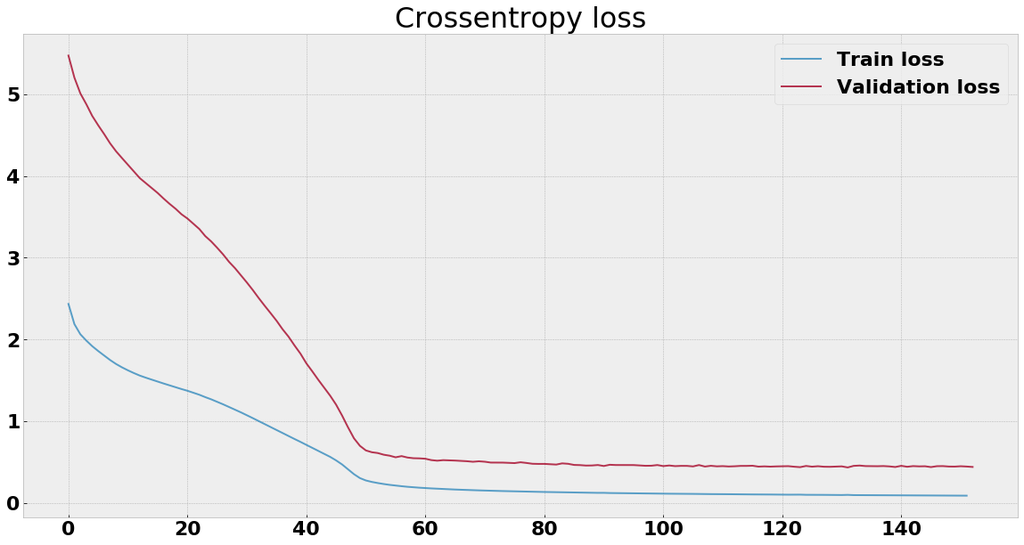

```
0.08824478354715448
0.43955144098732646
```

```python
data = pd.read_csv("C:/Users/jaiko/Desktop/MIOD/mio1/classification/rings3-balance-training.csv",header=0)
data.x = (data.x - data.x.mean())/data.x.std()
data.y = (data.y - data.y.mean())/data.y.std()
x = np.array(data.iloc[:,0:2]).T[:,:1500]
y = np.array(pd.get_dummies(data.c)).T[:,:1500]
x_val = np.array(data.iloc[:,0:2]).T[:,1500:]
y_val = np.array(pd.get_dummies(data.c)).T[:,1500:]


net = MLP(layers=[2, 10, 20, 10, 3],activations=['tanh','tanh','tanh','softmax'], init = "normal",
          loss_f = "logloss", early_stopping = True, iter_with_no_change=20,  tol = 1e-4)
loss1 = net.train(x, y, epochs=500, lr = 0.01, batch_size = 32, x_val = x_val, y_val = y_val)
_, a_s = net.feed_forward(x)
loss_val = net.validation_loss
a = len(loss1)
b = len(loss_val)
fig = plt.figure(figsize = [20,10])
ax = plt.subplot(111)
plt.plot(range(a), loss1, alpha = 0.8, markersize = 4, label = "Train loss")
plt.plot(range(b), loss_val, alpha = 0.8, markersize = 4, label = "Validation loss")
plt.title('Crossentropy loss')
ax.legend()
plt.show()
print(loss1[-1])
print(loss_val[-1])
```

The training process was carried out on the rings 3-balance set, as we can see early stopping, meant that the learning process ended when the loss function ceased to decrease on the validation set, thanks to this operation we can avoid overfiting.

# Regularization

## Classification

### Rings3-balance

#### Training loss

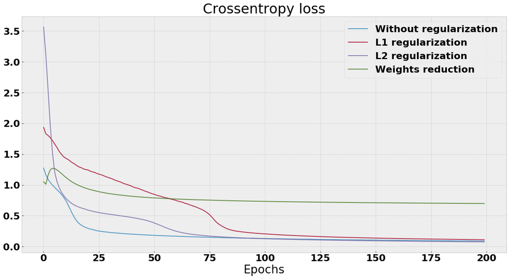

```python
data = pd.read_csv("C:/Users/jaiko/Desktop/MIOD/mio1/classification/rings3-balance-training.csv",header=0)
data.x = (data.x - data.x.mean())/data.x.std()
data.y = (data.y - data.y.mean())/data.y.std()
x = np.array(data.iloc[:,0:2]).T[:,:1500]
y = np.array(pd.get_dummies(data.c)).T[:,:1500]
x_val = np.array(data.iloc[:,0:2]).T[:,1500:]
y_val = np.array(pd.get_dummies(data.c)).T[:,1500:]


net = MLP(layers=[2, 10, 20, 10, 3],activations=['tanh','tanh','tanh','softmax'], init = "normal",
          loss_f = "logloss")
loss1 = net.train(x, y, epochs=200, lr = 0.01, batch_size = 32, x_val = x_val, y_val = y_val)

net = MLP(layers=[2, 10, 20, 10, 3],activations=['tanh','tanh','tanh','softmax'], init = "normal",
          loss_f = "logloss", l1 = True)
loss2 = net.train(x, y, epochs=200, lr = 0.01, batch_size = 32, x_val = x_val, y_val = y_val)

net = MLP(layers=[2, 10, 20, 10, 3],activations=['tanh','tanh','tanh','softmax'], init = "normal",
          loss_f = "logloss", l2 = True)
loss3 = net.train(x, y, epochs=200, lr = 0.01, batch_size = 32, x_val = x_val, y_val = y_val)

net = MLP(layers=[2, 10, 20, 10, 3],activations=['tanh','tanh','tanh','softmax'], init = "normal",
          loss_f = "logloss", decay = True)
loss4 = net.train(x, y, epochs=200, lr = 0.01, batch_size = 32, x_val = x_val, y_val = y_val)


a = len(loss1)

fig = plt.figure(figsize = [20,10])
ax = plt.subplot(111)
plt.plot(range(a), loss1, alpha = 0.8, markersize = 4, label = "Without regularization")
plt.plot(range(a), loss2, alpha = 0.8, markersize = 4, label = "L1 regularization")
plt.plot(range(a), loss3, alpha = 0.8, markersize = 4, label = "L2 regularization")
plt.plot(range(a), loss4, alpha = 0.8, markersize = 4, label = "Weights reduction")
plt.title('Crossentropy loss')
plt.xlabel("Epochs")
ax.legend()
plt.show()
```

#### Validation loss

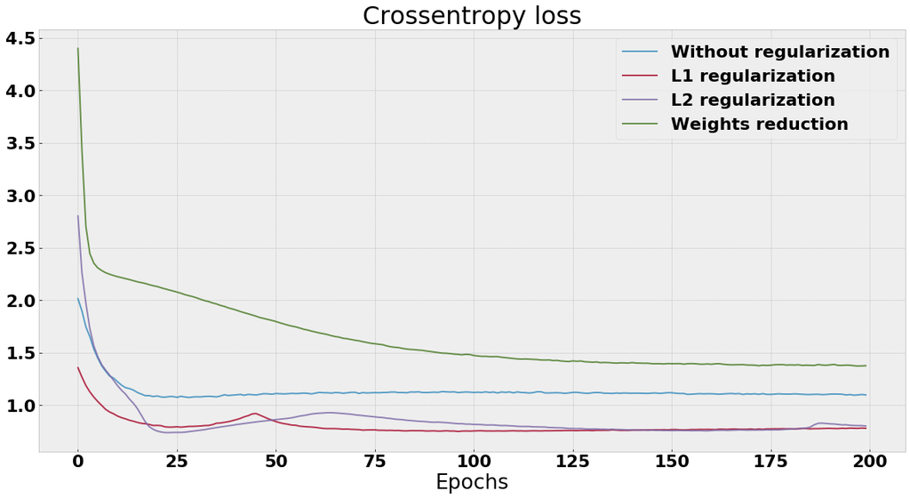

```python
data = pd.read_csv("C:/Users/jaiko/Desktop/MIOD/mio1/classification/rings3-balance-training.csv",header=0)
data.x = (data.x - data.x.mean())/data.x.std()
data.y = (data.y - data.y.mean())/data.y.std()
x = np.array(data.iloc[:,0:2]).T[:,:1500]
y = np.array(pd.get_dummies(data.c)).T[:,:1500]
x_val = np.array(data.iloc[:,0:2]).T[:,1500:]
y_val = np.array(pd.get_dummies(data.c)).T[:,1500:]




net = MLP(layers=[2, 10, 20, 10, 3],activations=['tanh','tanh','tanh','softmax'], init = "normal",
          loss_f = "logloss",early_stopping = True, iter_with_no_change=200,  tol = 1e-4)
loss1 = net.train(x, y, epochs=200, lr = 0.01, batch_size = 32, x_val = x_val, y_val = y_val)
loss_val1 = net.validation_loss
net = MLP(layers=[2, 10, 20, 10, 3],activations=['tanh','tanh','tanh','softmax'], init = "normal",
          loss_f = "logloss", l1 = True,early_stopping = True, iter_with_no_change=200,  tol = 1e-4)
loss2 = net.train(x, y, epochs=200, lr = 0.01, batch_size = 32, x_val = x_val, y_val = y_val)
loss_val2 = net.validation_loss
net = MLP(layers=[2, 10, 20, 10, 3],activations=['tanh','tanh','tanh','softmax'], init = "normal",
          loss_f = "logloss", l2 = True,early_stopping = True, iter_with_no_change=200,  tol = 1e-4)
loss3 = net.train(x, y, epochs=200, lr = 0.01, batch_size = 32, x_val = x_val, y_val = y_val)
loss_val3 = net.validation_loss
net = MLP(layers=[2, 10, 20, 10, 3],activations=['tanh','tanh','tanh','softmax'], init = "normal",
          loss_f = "logloss", decay = True,early_stopping = True, iter_with_no_change=200,  tol = 1e-4)
loss4 = net.train(x, y, epochs=200, lr = 0.01, batch_size = 32, x_val = x_val, y_val = y_val)
loss_val4 = net.validation_loss


a = len(loss_val2)

fig = plt.figure(figsize = [20,10])
ax = plt.subplot(111)
plt.plot(range(a), loss_val1, alpha = 0.8, markersize = 4, label = "Without regularization")
plt.plot(range(a), loss_val2, alpha = 0.8, markersize = 4, label = "L1 regularization")
plt.plot(range(a), loss_val3, alpha = 0.8, markersize = 4, label = "L2 regularization")
plt.plot(range(a), loss_val4, alpha = 0.8, markersize = 4, label = "Weights reduction")
plt.title('Crossentropy loss')
plt.xlabel("Epochs")
ax.legend()
plt.show()
```

## xor3-balance

### Training data

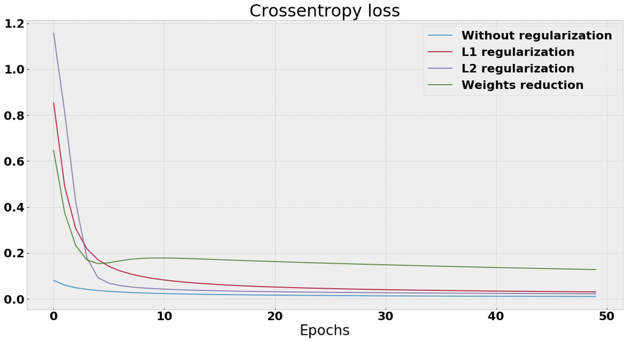

```python
data = pd.read_csv("C:/Users/jaiko/Desktop/MIOD/mio1/classification/xor3-balance-training.csv",header=0)
data.x = (data.x - data.x.mean())/data.x.std()
data.y = (data.y - data.y.mean())/data.y.std()
x = np.array(data.iloc[:,0:2]).T[:,:700]
y = np.array(pd.get_dummies(data.c)).T[:,:700]
x_val = np.array(data.iloc[:,0:2]).T[:,700:]
y_val = np.array(pd.get_dummies(data.c)).T[:,700:]


net = MLP(layers=[2, 10, 20, 10, 2],activations=['tanh','tanh','tanh','softmax'], init = "normal",
          loss_f = "logloss")
loss1 = net.train(x, y, epochs=50, lr = 0.01, batch_size = 32, x_val = x_val, y_val = y_val)

net = MLP(layers=[2, 10, 20, 10, 2],activations=['tanh','tanh','tanh','softmax'], init = "normal",
          loss_f = "logloss", l1 = True)
loss2 = net.train(x, y, epochs=50, lr = 0.01, batch_size = 32, x_val = x_val, y_val = y_val)

net = MLP(layers=[2, 10, 20, 10, 2],activations=['tanh','tanh','tanh','softmax'], init = "normal",
          loss_f = "logloss", l2 = True)
loss3 = net.train(x, y, epochs=50, lr = 0.01, batch_size = 32, x_val = x_val, y_val = y_val)

net = MLP(layers=[2, 10, 20, 10, 2],activations=['tanh','tanh','tanh','softmax'], init = "normal",
          loss_f = "logloss", decay = True)
loss4 = net.train(x, y, epochs=50, lr = 0.01, batch_size = 32, x_val = x_val, y_val = y_val)


a = len(loss1)

fig = plt.figure(figsize = [20,10])
ax = plt.subplot(111)
plt.plot(range(a), loss1, alpha = 0.8, markersize = 4, label = "Without regularization")
plt.plot(range(a), loss2, alpha = 0.8, markersize = 4, label = "L1 regularization")
plt.plot(range(a), loss3, alpha = 0.8, markersize = 4, label = "L2 regularization")
plt.plot(range(a), loss4, alpha = 0.8, markersize = 4, label = "Weights reduction")
plt.title('Crossentropy loss')
plt.xlabel("Epochs")
ax.legend()
plt.show()
```

### Validation data

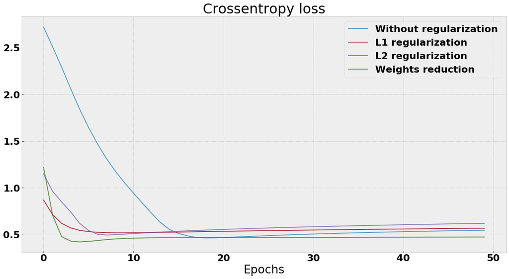

```python
data = pd.read_csv("C:/Users/jaiko/Desktop/MIOD/mio1/classification/xor3-balance-training.csv",header=0)
data.x = (data.x - data.x.mean())/data.x.std()
data.y = (data.y - data.y.mean())/data.y.std()
x = np.array(data.iloc[:,0:2]).T[:,:700]
y = np.array(pd.get_dummies(data.c)).T[:,:700]
x_val = np.array(data.iloc[:,0:2]).T[:,700:]
y_val = np.array(pd.get_dummies(data.c)).T[:,700:]




net = MLP(layers=[2, 10, 20, 10, 2],activations=['tanh','tanh','tanh','softmax'], init = "normal",
          loss_f = "logloss",early_stopping = True, iter_with_no_change=200,  tol = 1e-4)
loss1 = net.train(x, y, epochs=50, lr = 0.01, batch_size = 32, x_val = x_val, y_val = y_val)
loss_val1 = net.validation_loss
net = MLP(layers=[2, 10, 20, 10, 2],activations=['tanh','tanh','tanh','softmax'], init = "normal",
          loss_f = "logloss", l1 = True,early_stopping = True, iter_with_no_change=200,  tol = 1e-4)
loss2 = net.train(x, y, epochs=50, lr = 0.01, batch_size = 32, x_val = x_val, y_val = y_val)
loss_val2 = net.validation_loss
net = MLP(layers=[2, 10, 20, 10, 2],activations=['tanh','tanh','tanh','softmax'], init = "normal",
          loss_f = "logloss", l2 = True,early_stopping = True, iter_with_no_change=200,  tol = 1e-4)
loss3 = net.train(x, y, epochs=50, lr = 0.01, batch_size = 32, x_val = x_val, y_val = y_val)
loss_val3 = net.validation_loss
net = MLP(layers=[2, 10, 20, 10, 2],activations=['tanh','tanh','tanh','softmax'], init = "normal",
          loss_f = "logloss", decay = True,early_stopping = True, iter_with_no_change=200,  tol = 1e-4)
loss4 = net.train(x, y, epochs=50, lr = 0.01, batch_size = 32, x_val = x_val, y_val = y_val)
loss_val4 = net.validation_loss

a = len(loss_val2)

fig = plt.figure(figsize = [20,10])
ax = plt.subplot(111)
plt.plot(range(a), loss_val1, alpha = 0.8, markersize = 4, label = "Without regularization")
plt.plot(range(a), loss_val2, alpha = 0.8, markersize = 4, label = "L1 regularization")
plt.plot(range(a), loss_val3, alpha = 0.8, markersize = 4, label = "L2 regularization")
plt.plot(range(a), loss_val4, alpha = 0.8, markersize = 4, label = "Weights reduction")
plt.title('Crossentropy loss')
plt.xlabel("Epochs")
ax.legend()
plt.show()
```

### Rings 5 sparse

#### Training data

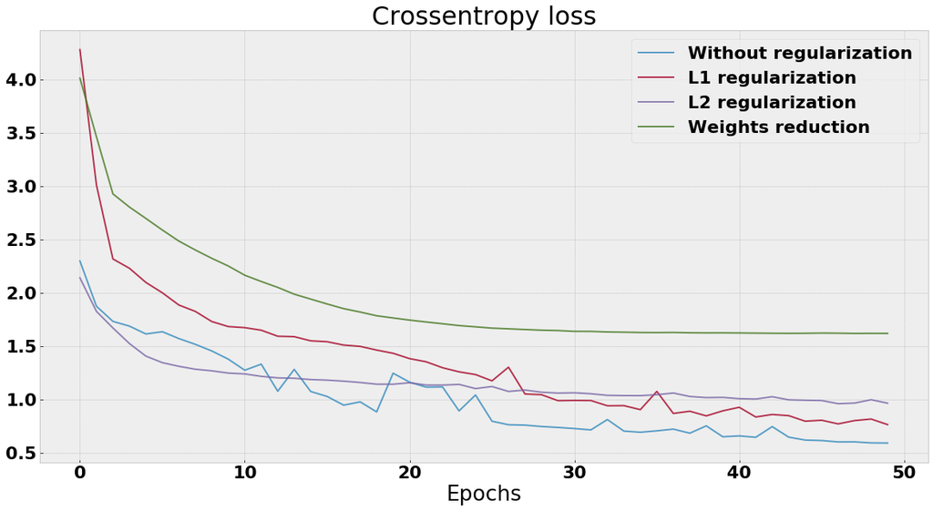

```python
data = pd.read_csv("C:/Users/jaiko/Desktop/MIOD/mio1/classification/rings5-sparse-training.csv",header=0)
data.x = (data.x - data.x.mean())/data.x.std()
data.y = (data.y - data.y.mean())/data.y.std()
datay = np.array(data.y).T.reshape(1,-1)
shuffle = np.random.permutation(datay.shape[1])
x = np.array(data.iloc[:,0:2]).T[:,shuffle][:,:200]
y = np.array(pd.get_dummies(data.c)).T[:,shuffle][:,:200]
x_val = np.array(data.iloc[:,0:2]).T[:,shuffle][:,700:]
y_val = np.array(pd.get_dummies(data.c)).T[:,shuffle][:,700:]


net = MLP(layers=[2, 10, 20, 10, 5],activations=['tanh','tanh','tanh','softmax'], init = "normal",
          loss_f = "logloss")
loss1 = net.train(x, y, epochs=50, lr = 0.1, batch_size = 32, x_val = x_val, y_val = y_val)

net = MLP(layers=[2, 10, 20, 10, 5],activations=['tanh','tanh','tanh','softmax'], init = "normal",
          loss_f = "logloss", l1 = True)
loss2 = net.train(x, y, epochs=50, lr = 0.1, batch_size = 32, x_val = x_val, y_val = y_val)

net = MLP(layers=[2, 10, 20, 10, 5],activations=['tanh','tanh','tanh','softmax'], init = "normal",
          loss_f = "logloss", l2 = True)
loss3 = net.train(x, y, epochs=50, lr = 0.1, batch_size = 32, x_val = x_val, y_val = y_val)

net = MLP(layers=[2, 10, 20, 10, 5],activations=['tanh','tanh','tanh','softmax'], init = "normal",
          loss_f = "logloss", decay = True)
loss4 = net.train(x, y, epochs=50, lr = 0.1, batch_size = 32, x_val = x_val, y_val = y_val)


a = len(loss1)

fig = plt.figure(figsize = [20,10])
ax = plt.subplot(111)
plt.plot(range(a), loss1, alpha = 0.8, markersize = 4, label = "Without regularization")
plt.plot(range(a), loss2, alpha = 0.8, markersize = 4, label = "L1 regularization")
plt.plot(range(a), loss3, alpha = 0.8, markersize = 4, label = "L2 regularization")
plt.plot(range(a), loss4, alpha = 0.8, markersize = 4, label = "Weights reduction")
plt.title('Crossentropy loss')
plt.xlabel("Epochs")
ax.legend()
plt.show()
```

#### Validation Data

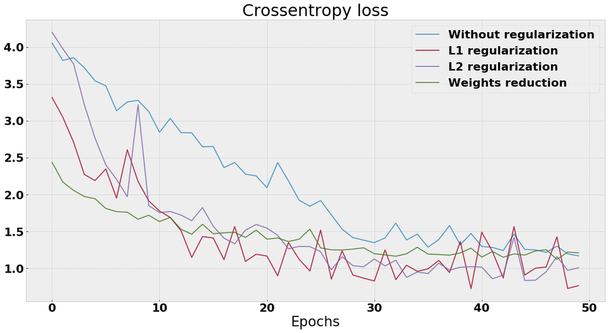

```python
data = pd.read_csv("C:/Users/jaiko/Desktop/MIOD/mio1/classification/rings5-sparse-training.csv",header=0)
data.x = (data.x - data.x.mean())/data.x.std()
data.y = (data.y - data.y.mean())/data.y.std()
datay = np.array(data.y).T.reshape(1,-1)
shuffle = np.random.permutation(datay.shape[1])
x = np.array(data.iloc[:,0:2]).T[:,shuffle][:,:150]
y = np.array(pd.get_dummies(data.c)).T[:,shuffle][:,:150]
x_val = np.array(data.iloc[:,0:2]).T[:,shuffle][:,150:]
y_val = np.array(pd.get_dummies(data.c)).T[:,shuffle][:,150:]




net = MLP(layers=[2, 10, 20, 10, 5],activations=['tanh','tanh','tanh','softmax'], init = "normal",
          loss_f = "logloss",early_stopping = True, iter_with_no_change=200,  tol = 1e-4)
loss1 = net.train(x, y, epochs=50, lr = 1, batch_size = 32, x_val = x_val, y_val = y_val)
loss_val1 = net.validation_loss
net = MLP(layers=[2, 10, 20, 10, 5],activations=['tanh','tanh','tanh','softmax'], init = "normal",
          loss_f = "logloss", l1 = True,early_stopping = True, iter_with_no_change=200,  tol = 1e-4)
loss2 = net.train(x, y, epochs=50, lr = 1, batch_size = 32, x_val = x_val, y_val = y_val)
loss_val2 = net.validation_loss
net = MLP(layers=[2, 10, 20, 10, 5],activations=['tanh','tanh','tanh','softmax'], init = "normal",
          loss_f = "logloss", l2 = True,early_stopping = True, iter_with_no_change=200,  tol = 1e-4)
loss3 = net.train(x, y, epochs=50, lr = 1, batch_size = 32, x_val = x_val, y_val = y_val)
loss_val3 = net.validation_loss
net = MLP(layers=[2, 10, 20, 10, 5],activations=['tanh','tanh','tanh','softmax'], init = "normal",
          loss_f = "logloss", decay = True,early_stopping = True, iter_with_no_change=200,  tol = 1e-4)
loss4 = net.train(x, y, epochs=50, lr = 1, batch_size = 32, x_val = x_val, y_val = y_val)
loss_val4 = net.validation_loss

a = len(loss_val2)

fig = plt.figure(figsize = [20,10])
ax = plt.subplot(111)
plt.plot(range(a), loss_val1, alpha = 0.8, markersize = 4, label = "Without regularization")
plt.plot(range(a), loss_val2, alpha = 0.8, markersize = 4, label = "L1 regularization")
plt.plot(range(a), loss_val3, alpha = 0.8, markersize = 4, label = "L2 regularization")
plt.plot(range(a), loss_val4, alpha = 0.8, markersize = 4, label = "Weights reduction")
plt.title('Crossentropy loss')
plt.xlabel("Epochs")
ax.legend()
plt.show()
```

## Regression

#### Training data

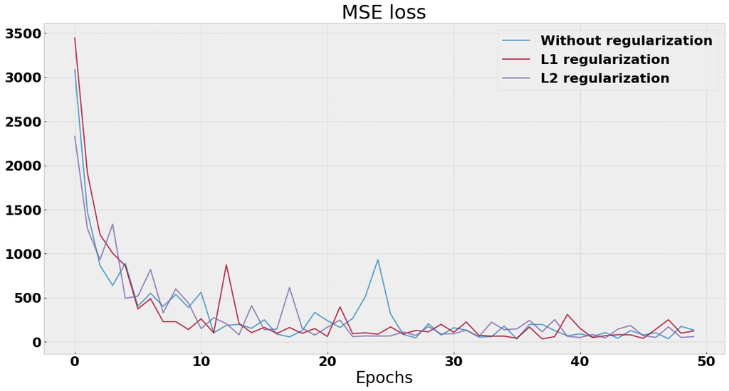

```python
data = pd.read_csv("C:/Users/jaiko/Desktop/MIOD/mio1/regression/multimodal-large-training.csv",header=0)
data.x = (data.x - data.x.mean())/data.x.std()
datax = np.array(data.x).T.reshape(1,-1)
datay = np.array(data.y).T.reshape(1,-1)
shuffle = np.random.permutation(datay.shape[1])
datax = datax[:,shuffle]
datay = datay[:,shuffle]
x = datax[:,:2000]
y = datay[:,:2000]
x_val = datax[:,6000:7000]
y_val = datay[:,6000:7000]



net = MLP(layers=[1, 10, 20, 10, 1],activations=['sigmoid', 'sigmoid', 'sigmoid', 'linear'], init = "normal",
          loss_f = "mse")
loss1 = net.train(x, y, epochs=50, lr = 0.01, batch_size = 32, x_val = x_val, y_val = y_val)

net = MLP(layers=[1, 10, 20, 10, 1],activations=['sigmoid', 'sigmoid', 'sigmoid', 'linear'], init = "normal",
          loss_f = "mse", l1 = True)
loss2 = net.train(x, y, epochs=50, lr = 0.01, batch_size = 32, x_val = x_val, y_val = y_val)

net = MLP(layers=[1, 10, 20, 10, 1],activations=['sigmoid', 'sigmoid', 'sigmoid', 'linear'], init = "normal",
          loss_f = "mse", l2 = True)
loss3 = net.train(x, y, epochs=50, lr = 0.01, batch_size = 32, x_val = x_val, y_val = y_val)

net = MLP(layers=[1, 10, 20, 10, 1],activations=['sigmoid', 'sigmoid', 'sigmoid', 'linear'], init = "normal",
          loss_f = "mse", decay = True)
loss4 = net.train(x, y, epochs=50, lr = 0.01, batch_size = 32, x_val = x_val, y_val = y_val)


a = len(loss1)

fig = plt.figure(figsize = [20,10])
ax = plt.subplot(111)
plt.plot(range(a), loss1, alpha = 0.8, markersize = 4, label = "Without regularization")
plt.plot(range(a), loss2, alpha = 0.8, markersize = 4, label = "L1 regularization")
plt.plot(range(a), loss3, alpha = 0.8, markersize = 4, label = "L2 regularization")
plt.title('MSE loss')
plt.xlabel("Epochs")
ax.legend()
plt.show()
```

#### Validation data

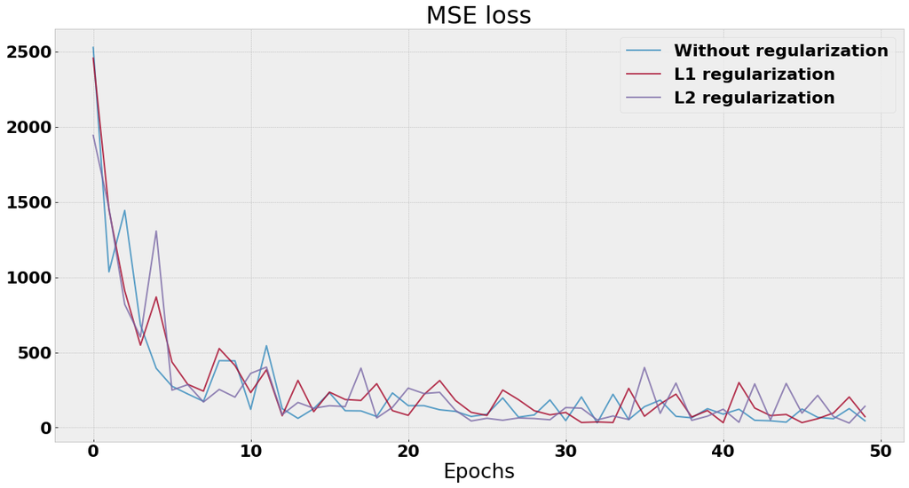

```python
data = pd.read_csv("C:/Users/jaiko/Desktop/MIOD/mio1/regression/multimodal-large-training.csv",header=0)
data.x = (data.x - data.x.mean())/data.x.std()
datax = np.array(data.x).T.reshape(1,-1)
datay = np.array(data.y).T.reshape(1,-1)
shuffle = np.random.permutation(datay.shape[1])
datax = datax[:,shuffle]
datay = datay[:,shuffle]
x = datax[:,:2000]
y = datay[:,:2000]
x_val = datax[:,6000:7000]
y_val = datay[:,6000:7000]



net = MLP(layers=[1, 10, 20, 10, 1],activations=['sigmoid', 'sigmoid', 'sigmoid', 'linear'], init = "normal",
          loss_f = "mse",early_stopping = True, iter_with_no_change=200,  tol = 1e-4)
loss1 = net.train(x, y, epochs=50, lr = 0.01, batch_size = 32, x_val = x_val, y_val = y_val)
loss_val1 = net.validation_loss
net = MLP(layers=[1, 10, 20, 10, 1],activations=['sigmoid', 'sigmoid', 'sigmoid', 'linear'], init = "normal",
          loss_f = "mse", l1 = True,early_stopping = True, iter_with_no_change=200,  tol = 1e-4)
loss2 = net.train(x, y, epochs=50, lr = 0.01, batch_size = 32, x_val = x_val, y_val = y_val)
loss_val2 = net.validation_loss
net = MLP(layers=[1, 10, 20, 10, 1],activations=['sigmoid', 'sigmoid', 'sigmoid', 'linear'], init = "normal",
          loss_f = "mse", l2 = True,early_stopping = True, iter_with_no_change=200,  tol = 1e-4)
loss3 = net.train(x, y, epochs=50, lr = 0.01, batch_size = 32, x_val = x_val, y_val = y_val)
loss_val3 = net.validation_loss
net = MLP(layers=[1, 10, 20, 10, 1],activations=['sigmoid', 'sigmoid', 'sigmoid', 'linear'], init = "normal",
          loss_f = "mse", decay = True,early_stopping = True, iter_with_no_change=200,  tol = 1e-4)
loss4 = net.train(x, y, epochs=50, lr = 0.01, batch_size = 32, x_val = x_val, y_val = y_val)
loss_val4 = net.validation_loss

a = len(loss_val2)

fig = plt.figure(figsize = [20,10])
ax = plt.subplot(111)
plt.plot(range(a), loss_val1, alpha = 0.8, markersize = 4, label = "Without regularization")
plt.plot(range(a), loss_val2, alpha = 0.8, markersize = 4, label = "L1 regularization")
plt.plot(range(a), loss_val3, alpha = 0.8, markersize = 4, label = "L2 regularization")
plt.title('MSE loss')
plt.xlabel("Epochs")
ax.legend()
plt.show()
```

### Dropout on validation set

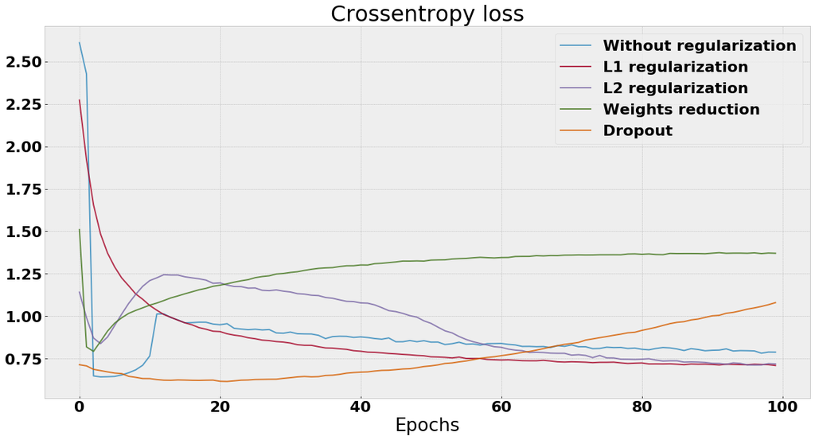

```python
data = pd.read_csv("C:/Users/jaiko/Desktop/MIOD/mio1/classification/rings3-balance-training.csv",header=0)
data.x = (data.x - data.x.mean())/data.x.std()
data.y = (data.y - data.y.mean())/data.y.std()
x = np.array(data.iloc[:,0:2]).T[:,:1500]
y = np.array(pd.get_dummies(data.c)).T[:,:1500]
x_val = np.array(data.iloc[:,0:2]).T[:,1500:]
y_val = np.array(pd.get_dummies(data.c)).T[:,1500:]




net = MLP(layers=[2, 10, 20, 10, 3],activations=['tanh','tanh','tanh','softmax'], init = "normal",
          loss_f = "logloss",early_stopping = True, iter_with_no_change=200,  tol = 1e-4)
loss1 = net.train(x, y, epochs=100, lr = 0.01, batch_size = 32, x_val = x_val, y_val = y_val)
loss_val1 = net.validation_loss
net = MLP(layers=[2, 10, 20, 10, 3],activations=['tanh','tanh','tanh','softmax'], init = "normal",
          loss_f = "logloss", l1 = True,early_stopping = True, iter_with_no_change=200,  tol = 1e-4)
loss2 = net.train(x, y, epochs=100, lr = 0.01, batch_size = 32, x_val = x_val, y_val = y_val)
loss_val2 = net.validation_loss
net = MLP(layers=[2, 10, 20, 10, 3],activations=['tanh','tanh','tanh','softmax'], init = "normal",
          loss_f = "logloss", l2 = True,early_stopping = True, iter_with_no_change=200,  tol = 1e-4)
loss3 = net.train(x, y, epochs=100, lr = 0.01, batch_size = 32, x_val = x_val, y_val = y_val)
loss_val3 = net.validation_loss
net = MLP(layers=[2, 10, 20, 10, 3],activations=['tanh','tanh','tanh','softmax'], init = "normal",
          loss_f = "logloss", decay = True,early_stopping = True, iter_with_no_change=200,  tol = 1e-4)
loss4 = net.train(x, y, epochs=100, lr = 0.01, batch_size = 32, x_val = x_val, y_val = y_val)
loss_val4 = net.validation_loss
net = MLP(layers=[2, 20, 30, 20, 3],activations=['tanh','tanh','tanh','softmax'], init = "normal",
          loss_f = "logloss", drop_prob=0.1,early_stopping = True, iter_with_no_change=200,  tol = 1e-4)
loss5 = net.train(x, y, epochs=100, lr = 0.001, batch_size = 32, x_val = x_val, y_val = y_val)
loss_val5 = net.validation_loss


a = len(loss_val2)

fig = plt.figure(figsize = [20,10])
ax = plt.subplot(111)
plt.plot(range(a), loss_val1, alpha = 0.8, markersize = 4, label = "Without regularization")
plt.plot(range(a), loss_val2, alpha = 0.8, markersize = 4, label = "L1 regularization")
plt.plot(range(a), loss_val3, alpha = 0.8, markersize = 4, label = "L2 regularization")
plt.plot(range(a), loss_val4, alpha = 0.8, markersize = 4, label = "Weights reduction")
plt.plot(range(a), loss_val5, alpha = 0.8, markersize = 4, label = "Dropout")
plt.title('Crossentropy loss')
plt.xlabel("Epochs")
ax.legend()
plt.show()
```

Regularization is a method that helps prevent overfiting by limiting weight. It should improve the model's performance on data it did not learn, on the other hand, it can sometimes slow down and weaken learning on a training set by imposing weight restrictions. I usually received these results from my observations. Regularization often slowed down learning on the learning set, but helped to get better results on validation sets. This is particularly well seen in examples with classification. In the case of the regression example, the influence of regularization is not quite visible, it may be due to the type of architecture or data set. All types of regularization achieved quite good results in the case of classification on validation sets, however, on the training set artificial weight reduction usually did the worst.

## What regularization can give us

### rings3-balance

I will now conduct an experiment that will involve learning two networks on a training set and testing their effectiveness on a test set. The first one will not have any regularization methods, while in the second case I will use early stopping and L2 regularization.

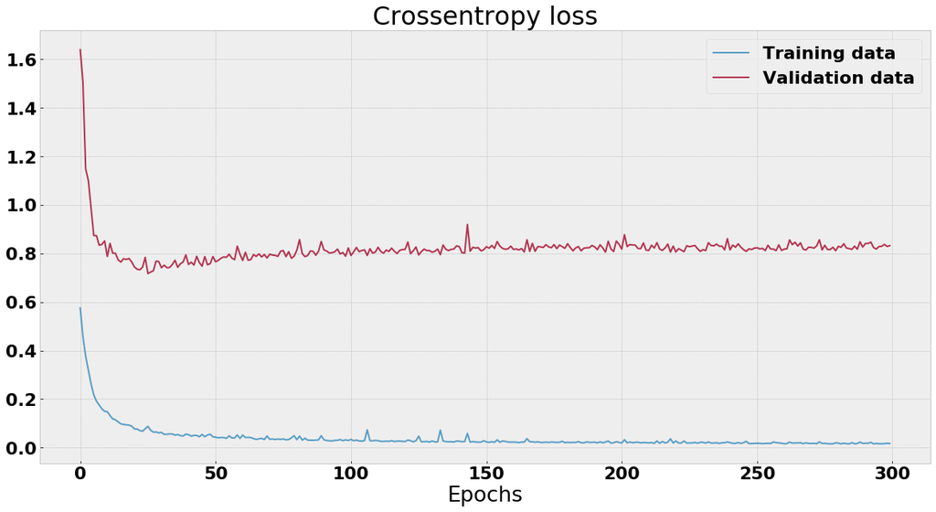

```
Logloss for test data prediction:
2.2906160218032094
```

```python
data = pd.read_csv("C:/Users/jaiko/Desktop/MIOD/mio1/classification/rings3-balance-training.csv",header=0)
data.x = (data.x - data.x.mean())/data.x.std()
data.y = (data.y - data.y.mean())/data.y.std()
x = np.array(data.iloc[:,0:2]).T[:,:1500]
y = np.array(pd.get_dummies(data.c)).T[:,:1500]
x_val = np.array(data.iloc[:,0:2]).T[:,1500:]
y_val = np.array(pd.get_dummies(data.c)).T[:,1500:]

data2 = pd.read_csv("C:/Users/jaiko/Desktop/MIOD/mio1/classification/rings3-balance-test.csv",header=0)
data2.x = (data2.x - data2.x.mean())/data2.x.std()
data2.y = (data2.y - data2.y.mean())/data2.y.std()
x2 = np.array(data2.iloc[:,0:2]).T
y2 = np.array(pd.get_dummies(data2.c)).T



net = MLP(layers=[2, 10, 20, 10, 3],activations=['tanh','tanh','tanh','softmax'], init = "normal",
          loss_f = "logloss",early_stopping = True, iter_with_no_change=300,  tol = 1e-4)
loss1 = net.train(x, y, epochs=300, lr = 0.1, batch_size = 32, x_val = x_val, y_val = y_val)
loss_val1 = net.validation_loss



a = len(loss_val1)

fig = plt.figure(figsize = [20,10])
ax = plt.subplot(111)
plt.plot(range(a), loss1, alpha = 0.8, markersize = 4, label = "Training data")
plt.plot(range(a), loss_val1, alpha = 0.8, markersize = 4, label = "Validation data")

plt.title('Crossentropy loss')
plt.xlabel("Epochs")
ax.legend()
plt.show()
before, after = net.feed_forward(x2,do_drop = False)
print("Logloss for test data prediction:")
print(log_loss(y2.T, after[-1].T))
```

### With regularization and early stopping

```
Early stop at: 29 epochs
```

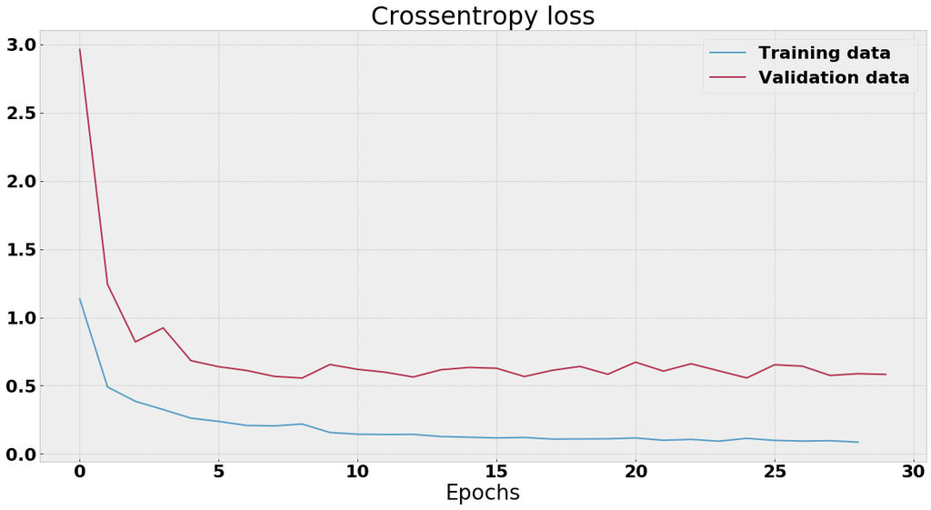

```
Logloss for test data prediction:
1.5598496309141954
```

```python
data = pd.read_csv("C:/Users/jaiko/Desktop/MIOD/mio1/classification/rings3-balance-training.csv",header=0)
data.x = (data.x - data.x.mean())/data.x.std()
data.y = (data.y - data.y.mean())/data.y.std()
x = np.array(data.iloc[:,0:2]).T[:,:1500]
y = np.array(pd.get_dummies(data.c)).T[:,:1500]
x_val = np.array(data.iloc[:,0:2]).T[:,1500:]
y_val = np.array(pd.get_dummies(data.c)).T[:,1500:]

data2 = pd.read_csv("C:/Users/jaiko/Desktop/MIOD/mio1/classification/rings3-balance-test.csv",header=0)
data2.x = (data2.x - data2.x.mean())/data2.x.std()
data2.y = (data2.y - data2.y.mean())/data2.y.std()
x2 = np.array(data2.iloc[:,0:2]).T
y2 = np.array(pd.get_dummies(data2.c)).T



net = MLP(layers=[2, 10, 20, 10, 3],activations=['tanh','tanh','tanh','softmax'], init = "normal",
          loss_f = "logloss",early_stopping = True, iter_with_no_change=20,  tol = 1e-4, l2 = True)
loss1 = net.train(x, y, epochs=300, lr = 0.1, batch_size = 32, x_val = x_val, y_val = y_val)
loss_val1 = net.validation_loss



a = len(loss_val1)
b = len(loss1)

fig = plt.figure(figsize = [20,10])
ax = plt.subplot(111)
plt.plot(range(b), loss1, alpha = 0.8, markersize = 4, label = "Training data")
plt.plot(range(a), loss_val1, alpha = 0.8, markersize = 4, label = "Validation data")

plt.title('Crossentropy loss')
plt.xlabel("Epochs")
ax.legend()
plt.show()
before, after = net.feed_forward(x2,do_drop = False)
print("Logloss for test data prediction:")
print(log_loss(y2.T, after[-1].T))
```

## Xor3-balance

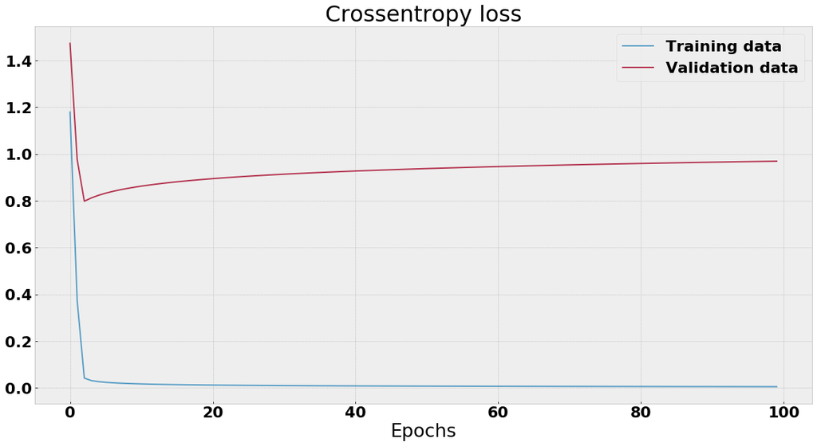

```
Logloss for test data prediction:
2.123735393446319
```

```python
data = pd.read_csv("C:/Users/jaiko/Desktop/MIOD/mio1/classification/xor3-balance-training.csv",header=0)
data.x = (data.x - data.x.mean())/data.x.std()
data.y = (data.y - data.y.mean())/data.y.std()
x = np.array(data.iloc[:,0:2]).T[:,:700]
y = np.array(pd.get_dummies(data.c)).T[:,:700]
x_val = np.array(data.iloc[:,0:2]).T[:,700:]
y_val = np.array(pd.get_dummies(data.c)).T[:,700:]

data2 = pd.read_csv("C:/Users/jaiko/Desktop/MIOD/mio1/classification/xor3-balance-test.csv",header=0)
data2.x = (data2.x - data2.x.mean())/data2.x.std()
data2.y = (data2.y - data2.y.mean())/data2.y.std()
x2 = np.array(data2.iloc[:,0:2]).T
y2 = np.array(pd.get_dummies(data2.c)).T



net = MLP(layers=[2, 10, 20, 10, 2],activations=['tanh','tanh','tanh','softmax'], init = "normal",
          loss_f = "logloss",early_stopping = True, iter_with_no_change=300,  tol = 1e-4)
loss1 = net.train(x, y, epochs=100, lr = 0.1, batch_size = 32, x_val = x_val, y_val = y_val)
loss_val1 = net.validation_loss



a = len(loss_val1)

fig = plt.figure(figsize = [20,10])
ax = plt.subplot(111)
plt.plot(range(a), loss1, alpha = 0.8, markersize = 4, label = "Training data")
plt.plot(range(a), loss_val1, alpha = 0.8, markersize = 4, label = "Validation data")

plt.title('Crossentropy loss')
plt.xlabel("Epochs")
ax.legend()
plt.show()
before, after = net.feed_forward(x2,do_drop = False)
print("Logloss for test data prediction:")
print(log_loss(y2.T, after[-1].T))
```

```
Early stop at: 22 epochs
```

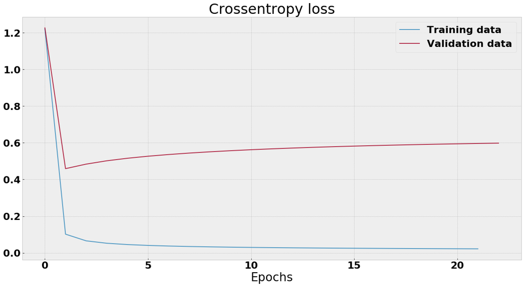

```
Logloss for test data prediction:
1.3432507048528666
```

```python
data = pd.read_csv("C:/Users/jaiko/Desktop/MIOD/mio1/classification/xor3-balance-training.csv",header=0)
data.x = (data.x - data.x.mean())/data.x.std()
data.y = (data.y - data.y.mean())/data.y.std()
x = np.array(data.iloc[:,0:2]).T[:,:700]
y = np.array(pd.get_dummies(data.c)).T[:,:700]
x_val = np.array(data.iloc[:,0:2]).T[:,700:]
y_val = np.array(pd.get_dummies(data.c)).T[:,700:]

data2 = pd.read_csv("C:/Users/jaiko/Desktop/MIOD/mio1/classification/xor3-balance-test.csv",header=0)
data2.x = (data2.x - data2.x.mean())/data2.x.std()
data2.y = (data2.y - data2.y.mean())/data2.y.std()
x2 = np.array(data2.iloc[:,0:2]).T
y2 = np.array(pd.get_dummies(data2.c)).T



net = MLP(layers=[2, 10, 20, 10, 2],activations=['tanh','tanh','tanh','softmax'], init = "normal",
          loss_f = "logloss",early_stopping = True, iter_with_no_change=20,  tol = 1e-4, l2 = True)
loss1 = net.train(x, y, epochs=100, lr = 0.1, batch_size = 32, x_val = x_val, y_val = y_val)
loss_val1 = net.validation_loss



a = len(loss_val1)
b = len(loss1)

fig = plt.figure(figsize = [20,10])
ax = plt.subplot(111)
plt.plot(range(b), loss1, alpha = 0.8, markersize = 4, label = "Training data")
plt.plot(range(a), loss_val1, alpha = 0.8, markersize = 4, label = "Validation data")

plt.title('Crossentropy loss')
plt.xlabel("Epochs")
ax.legend()
plt.show()
before, after = net.feed_forward(x2,do_drop = False)
print("Logloss for test data prediction:")
print(log_loss(y2.T, after[-1].T))
```

## Rings 5 sparse

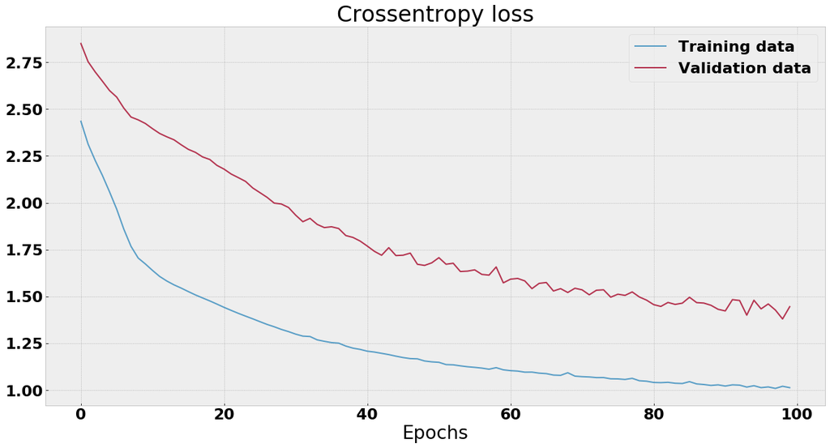

```
Logloss for test data prediction:
1.2617059431496938
```

```python
data = pd.read_csv("C:/Users/jaiko/Desktop/MIOD/mio1/classification/rings5-sparse-training.csv",header=0)
data.x = (data.x - data.x.mean())/data.x.std()
data.y = (data.y - data.y.mean())/data.y.std()
datay = np.array(data.y).T.reshape(1,-1)
shuffle = np.random.permutation(datay.shape[1])
x = np.array(data.iloc[:,0:2]).T[:,shuffle][:,:150]
y = np.array(pd.get_dummies(data.c)).T[:,shuffle][:,:150]
x_val = np.array(data.iloc[:,0:2]).T[:,shuffle][:,150:]
y_val = np.array(pd.get_dummies(data.c)).T[:,shuffle][:,150:]

data2 = pd.read_csv("C:/Users/jaiko/Desktop/MIOD/mio1/classification/rings5-sparse-test.csv",header=0)
data2.x = (data2.x - data2.x.mean())/data2.x.std()
data2.y = (data2.y - data2.y.mean())/data2.y.std()
x2 = np.array(data2.iloc[:,0:2]).T
y2 = np.array(pd.get_dummies(data2.c)).T



net = MLP(layers=[2, 10, 20, 10, 5],activations=['tanh','tanh','tanh','softmax'], init = "normal",
          loss_f = "logloss",early_stopping = True, iter_with_no_change=300,  tol = 1e-4)
loss1 = net.train(x, y, epochs=100, lr = 0.1, batch_size = 32, x_val = x_val, y_val = y_val)
loss_val1 = net.validation_loss



a = len(loss_val1)

fig = plt.figure(figsize = [20,10])
ax = plt.subplot(111)
plt.plot(range(a), loss1, alpha = 0.8, markersize = 4, label = "Training data")
plt.plot(range(a), loss_val1, alpha = 0.8, markersize = 4, label = "Validation data")

plt.title('Crossentropy loss')
plt.xlabel("Epochs")
ax.legend()
plt.show()
before, after = net.feed_forward(x2,do_drop = False)
print("Logloss for test data prediction:")
print(log_loss(y2.T, after[-1].T))
```

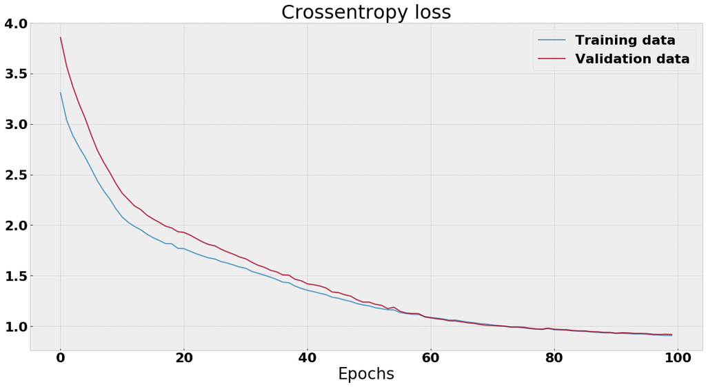

```
Logloss for test data prediction:
1.142853937249487
```

```python
data = pd.read_csv("C:/Users/jaiko/Desktop/MIOD/mio1/classification/rings5-sparse-training.csv",header=0)
data.x = (data.x - data.x.mean())/data.x.std()
data.y = (data.y - data.y.mean())/data.y.std()
datay = np.array(data.y).T.reshape(1,-1)
shuffle = np.random.permutation(datay.shape[1])
x = np.array(data.iloc[:,0:2]).T[:,shuffle][:,:150]
y = np.array(pd.get_dummies(data.c)).T[:,shuffle][:,:150]
x_val = np.array(data.iloc[:,0:2]).T[:,shuffle][:,150:]
y_val = np.array(pd.get_dummies(data.c)).T[:,shuffle][:,150:]

data2 = pd.read_csv("C:/Users/jaiko/Desktop/MIOD/mio1/classification/rings5-sparse-test.csv",header=0)
data2.x = (data2.x - data2.x.mean())/data2.x.std()
data2.y = (data2.y - data2.y.mean())/data2.y.std()
x2 = np.array(data2.iloc[:,0:2]).T
y2 = np.array(pd.get_dummies(data2.c)).T



net = MLP(layers=[2, 10, 20, 10, 5],activations=['tanh','tanh','tanh','softmax'], init = "normal",
          loss_f = "logloss",early_stopping = True, iter_with_no_change=20,  tol = 1e-4, l2 = True)
loss1 = net.train(x, y, epochs=100, lr = 0.1, batch_size = 32, x_val = x_val, y_val = y_val)
loss_val1 = net.validation_loss



a = len(loss_val1)
b = len(loss1)

fig = plt.figure(figsize = [20,10])
ax = plt.subplot(111)
plt.plot(range(b), loss1, alpha = 0.8, markersize = 4, label = "Training data")
plt.plot(range(a), loss_val1, alpha = 0.8, markersize = 4, label = "Validation data")

plt.title('Crossentropy loss')
plt.xlabel("Epochs")
ax.legend()
plt.show()
before, after = net.feed_forward(x2,do_drop = False)
print("Logloss for test data prediction:")
print(log_loss(y2.T, after[-1].T))
```

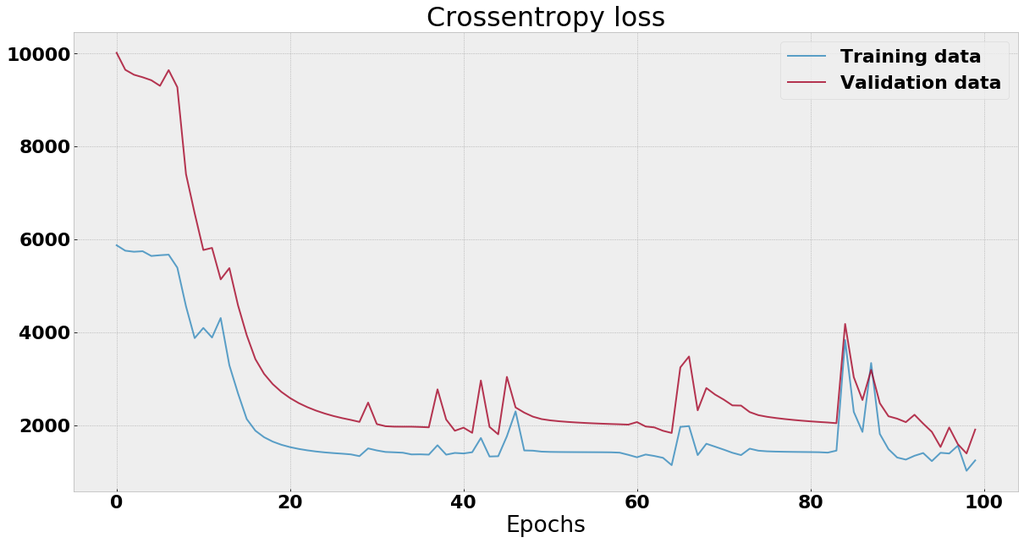

```
MSE for test data prediction:
1112.9875215272953
```

```python
data = pd.read_csv("C:/Users/jaiko/Desktop/MIOD/mio1/regression/multimodal-sparse-training.csv",header=0)
data.x = (data.x - data.x.mean())/data.x.std()
datax = np.array(data.x).T.reshape(1,-1)
datay = np.array(data.y).T.reshape(1,-1)
shuffle = np.random.permutation(datay.shape[1])
datax = datax[:,shuffle]
datay = datay[:,shuffle]
x = datax[:,:30]
y = datay[:,:30]
x_val = datax[:,30:]
y_val = datay[:,30:]

data2 = pd.read_csv("C:/Users/jaiko/Desktop/MIOD/mio1/regression/multimodal-sparse-test.csv",header=0)
data2.x = (data2.x - data2.x.mean())/data2.x.std()
datax2 = np.array(data2.x).T.reshape(1,-1)
datay2 = np.array(data2.y).T.reshape(1,-1)
x2 = datax
y2 = datay


net = MLP(layers=[1, 10, 20, 10, 1],activations=['sigmoid', 'sigmoid', 'sigmoid', 'linear'], init = "normal",
          loss_f = "mse",early_stopping = True, iter_with_no_change=300,  tol = 1e-4)
loss1 = net.train(x, y, epochs=100, lr = 0.1, batch_size = 32, x_val = x_val, y_val = y_val)
loss_val1 = net.validation_loss



a = len(loss_val1)

fig = plt.figure(figsize = [20,10])
ax = plt.subplot(111)
plt.plot(range(a), loss1, alpha = 0.8, markersize = 4, label = "Training data")
plt.plot(range(a), loss_val1, alpha = 0.8, markersize = 4, label = "Validation data")

plt.title('Crossentropy loss')
plt.xlabel("Epochs")
ax.legend()
plt.show()
before, after = net.feed_forward(x2,do_drop = False)
print("MSE for test data prediction:")
print(MLP.mse(y2.T, after[-1].T))
```

```
Early stop at: 82 epochs
```

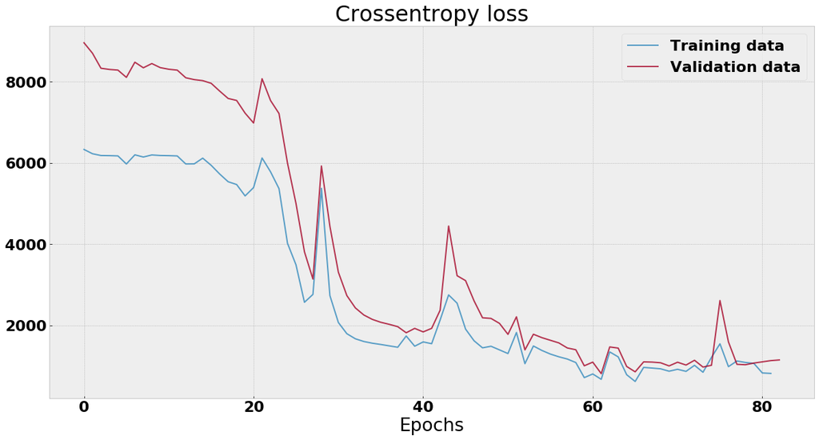

```
MSE for test data prediction:
706.4518303565674
```

```python
data = pd.read_csv("C:/Users/jaiko/Desktop/MIOD/mio1/regression/multimodal-sparse-training.csv",header=0)
data.x = (data.x - data.x.mean())/data.x.std()
datax = np.array(data.x).T.reshape(1,-1)
datay = np.array(data.y).T.reshape(1,-1)
shuffle = np.random.permutation(datay.shape[1])
datax = datax[:,shuffle]
datay = datay[:,shuffle]
x = datax[:,:30]
y = datay[:,:30]
x_val = datax[:,30:]
y_val = datay[:,30:]

data2 = pd.read_csv("C:/Users/jaiko/Desktop/MIOD/mio1/regression/multimodal-sparse-test.csv",header=0)
data2.x = (data2.x - data2.x.mean())/data2.x.std()
datax2 = np.array(data2.x).T.reshape(1,-1)
datay2 = np.array(data2.y).T.reshape(1,-1)
x2 = datax
y2 = datay



net = MLP(layers=[1, 10, 20, 10, 1],activations=['sigmoid', 'sigmoid', 'sigmoid', 'linear'], init = "normal",
          loss_f = "mse",early_stopping = True, iter_with_no_change=20,  tol = 1e-4, l2 = True)
loss1 = net.train(x, y, epochs=100, lr = 0.1, batch_size = 32, x_val = x_val, y_val = y_val)
loss_val1 = net.validation_loss



a = len(loss_val1)
b = len(loss1)

fig = plt.figure(figsize = [20,10])
ax = plt.subplot(111)
plt.plot(range(b), loss1, alpha = 0.8, markersize = 4, label = "Training data")
plt.plot(range(a), loss_val1, alpha = 0.8, markersize = 4, label = "Validation data")

plt.title('Crossentropy loss')
plt.xlabel("Epochs")
ax.legend()
plt.show()
before, after = net.feed_forward(x2,do_drop = False)
print("MSE for test data prediction:")
print(MLP.mse(y2.T, after[-1].T))
```

### Results

As you can see from the above results, regularization has helped our networks not over-adapt to learning data. During the experiments there were also such results when the model without regularization obtained better results. Early stopping often stopped our learning when we were no longer getting better.